# Generalised Least Squares & Non-linear Least Squares

2016-05-05

## Assumptions of Least Squares

1. The relationship between the response and the predictors is ~linear.
2. The residuals have a mean of zero.
3. **The residuals have constant variance (not heteroscedastic).**
4. The residuals are independent (uncorrelated).
5. The residuals are normally distributed.

Weighted least squares can be used when variance is not constant

## Weighted least squares

If observations have different amounts of uncertainty

Give uncertain observation less weight

– less influence on regression

Adjust weight matrix

W = weight matrix

k = sqrt(W)

```
##      [,1] [,2] [,3] [,4]
## [1,]    1    0    0    0
## [2,]    0    1    0    0
## [3,]    0    0    1    0
## [4,]    0    0    0    1
```

Default weight matrix - 1s on diagonal - 0s off diagonal

y<sub>i</sub> = β<sub>0</sub> + β<sub>1</sub>x<sub>i</sub> + ε<sub>i</sub>

k<sub>i</sub>y<sub>i</sub> = k<sub>i</sub>β<sub>0</sub> + k<sub>i</sub>β<sub>1</sub>x<sub>i</sub> + k<sub>i</sub>ε<sub>i</sub>

We adjust the influence of the point

‘We adjust the size of the residuals’

## Galton’s Peas

Pea sizes

| Parent | Progeny | SD |
| --- | --- | --- |
| 0.21 | 0.1726 | 0.01988 |
| 0.20 | 0.1707 | 0.01938 |
| 0.19 | 0.1637 | 0.01896 |
| 0.18 | 0.1640 | 0.02037 |
| 0.17 | 0.1613 | 0.01654 |
| 0.16 | 0.1617 | 0.01594 |
| 0.15 | 0.1598 | 0.01763 |

- Parent - pea diameter in inches of parent plant
- Progeny - mean pea diameter (inches) of up to 10 plants grown from seeds of the parent plant
- SD - standard deviation of offspring peas grown from each parent.

Standard deviations reflect information in the response

Downweight obervations with large standard deviation and upweight observations with a small standard deviation.

Use weighted least squares with weights equal to 1/SD<sup>2</sup>.

## In R

```r
mod <- lm(Progeny ~ Parent, data = peas)
summary(mod)$coef
```

```
##              Estimate  Std. Error  t value     Pr(>|t|)
## (Intercept) 0.1270286 0.006993245 18.16447 9.293731e-06
## Parent      0.2100000 0.038613733  5.43848 2.852305e-03
```

```r
wmod <- lm(Progeny ~ Parent, data = peas, weights = 1 / SD ^ 2)
summary(wmod)$coef
```

```
##              Estimate  Std. Error   t value     Pr(>|t|)
## (Intercept) 0.1279642 0.006811243 18.787197 7.868650e-06
## Parent      0.2048012 0.038154826  5.367635 3.020519e-03
```

Weighed regression assumes that the weights are precisely known

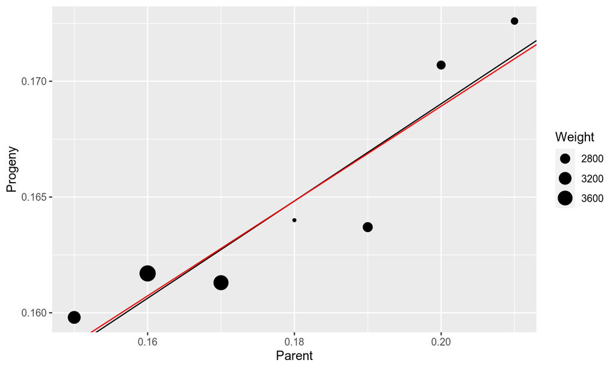

```r
ggplot(peas, aes(x = Parent, y = Progeny, size = 1 / SD ^ 2)) +
  geom_point() +
  geom_abline(intercept = coef(mod)[1], slope = coef(mod)[2], col = "black") +
  geom_abline(intercept = coef(wmod)[1], slope = coef(wmod)[2], col = "red") +
  labs(size = "Weight")
```

## Generalised least squares

Solution to non-constant variance (heteroscedastic data)

W = 1/var(response)

Fit using `gls` in package `nlme`.

## Bird1 dataset

Variances are different for each treatment

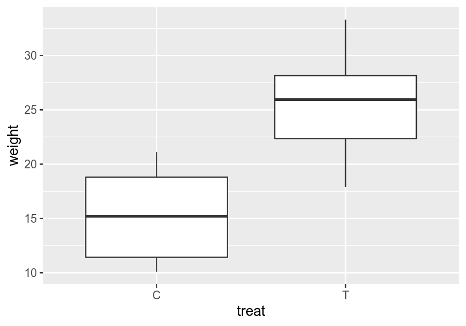

```r
ggplot(bird1, aes(x = treat, y = weight)) +
  geom_boxplot()
```

```r
bird1 %>% group_by(treat) %>%
  summarise(var = var(weight))
```

```
## # A tibble: 2 x 2
##   treat   var
## * <fct> <dbl>
## 1 C      17.7
## 2 T      22.0
```

## GLS

```r
library(nlme)
fit_gls <- gls(weight ~ treat, data = bird1, weights = varIdent(form = ~ +1|treat))
summary(fit_gls)
```

```
## Generalized least squares fit by REML
##   Model: weight ~ treat
##   Data: bird1
##        AIC      BIC    logLik
##   117.3734 120.9348 -54.68668
##
## Variance function:
##  Structure: Different standard deviations per stratum
##  Formula: ~+1 | treat
##  Parameter estimates:
##        C        T
## 1.000000 1.114728
##
## Coefficients:
##             Value Std.Error   t-value p-value
## (Intercept) 15.14  1.330682 11.377629       0
## treatT      10.57  1.992745  5.304241       0
##
##  Correlation:
##        (Intr)
## treatT -0.668
##
## Standardized residuals:
##         Min          Q1         Med          Q3         Max
## -1.66497663 -0.82289498  0.01425861  0.67497806  1.61807588
##
## Residual standard error: 4.207984
## Degrees of freedom: 20 total; 18 residual
```

## Model comparison

```r
fit_0 <- gls(weight ~ treat, data = bird1)
anova(fit_0, fit_gls)
```

```
##         Model df      AIC      BIC    logLik   Test   L.Ratio p-value
## fit_0       1  3 115.4793 118.1504 -54.73966
## fit_gls     2  4 117.3734 120.9348 -54.68668 1 vs 2 0.1059596  0.7448
```

## Other magic in GLS

Copes with spatially/temporally autocorrelated data

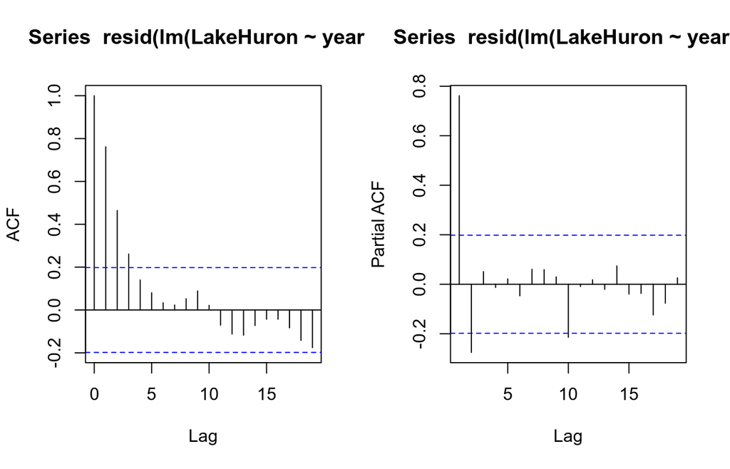

```r
year <- time(LakeHuron)
par(mfrow = c(1, 2))
acf(resid(lm(LakeHuron ~ year)))
pacf(resid(lm(LakeHuron ~ year)))
```

```r
par(mfrow = c(1, 1))
```

Many different correlation structures available. Choose appropriate one.

Change off-diagonal values in weights-matrix

```r
mod_ar1 <- gls(LakeHuron ~ year, corr = corAR1())
summary(mod_ar1)
```

```
## Generalized least squares fit by REML
##   Model: LakeHuron ~ year
##   Data: NULL
##        AIC      BIC    logLik
##   225.8304 236.0878 -108.9152
##
## Correlation Structure: AR(1)
##  Formula: ~1
##  Parameter estimate(s):
##       Phi
## 0.8247674
##
## Coefficients:
##                Value Std.Error   t-value p-value
## (Intercept) 616.4887 24.362632 25.304683  0.0000
## year         -0.0194  0.012664 -1.534616  0.1282
##
##  Correlation:
##      (Intr)
## year -1
##
## Standardized residuals:
##         Min          Q1         Med          Q3         Max
## -2.11192554 -0.57663992 -0.05772191  0.53782186  1.82271164
##
## Residual standard error: 1.260554
## Degrees of freedom: 98 total; 96 residual
```

## Non-linear least squares

## Assumptions of Least Squares

1. **The relationship between the response and the predictors is ~linear.**
2. The residuals have a mean of zero.
3. The residuals have constant variance (not heteroscedastic).
4. The residuals are independent (uncorrelated).
5. The residuals are normally distributed.

Nonlinear least squares can be used when relationship is non-linear.

## Non-linear least squares

We know something about the relationship

Upper or lower bound (asymptote)

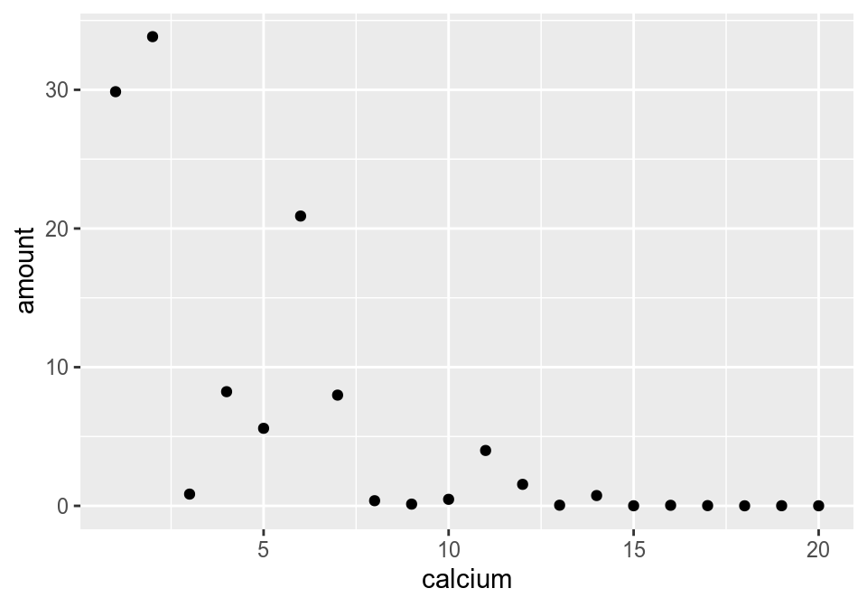

Three options

- Transform response
- Use polynomials (x2)
- Non-linear expression

Transformations:

- AVOID, statistics must be correct on transformed scale
- Log transform assumes that error is a constant proportion of the response

Polynomial

y<sub>i</sub> = β<sub>0</sub> + β<sub>1</sub>x<sub>i</sub> + β<sub>2</sub>x<sub>i</sub><sup>2</sup> + ε<sub>i</sub>

- Very useful
- But can give incorrect predictions

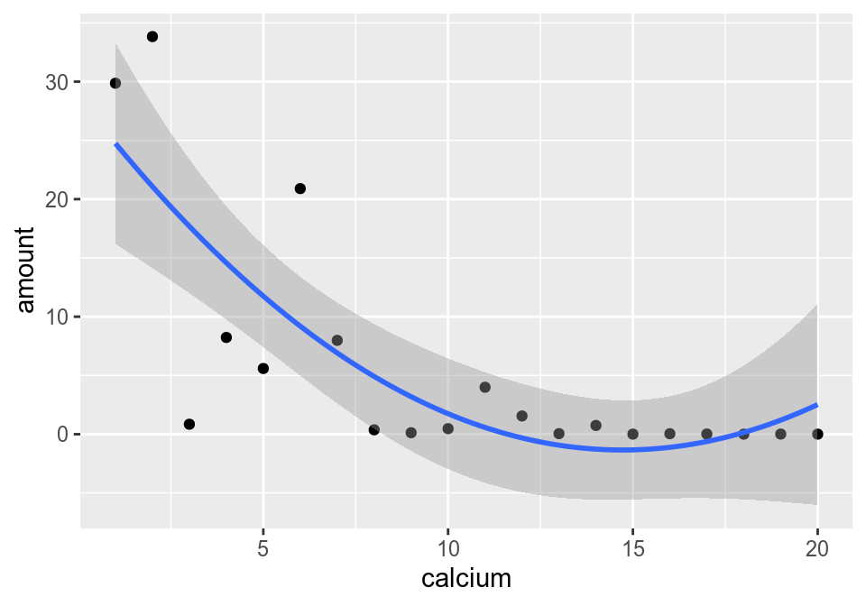

## NLS

The relationship has an asymptote, and a exponential decline

y<sub>i</sub> = β<sub>0</sub> + β<sub>1</sub> exp(β<sub>2</sub>x<sub>i</sub>) + ε<sub>i</sub>

- β<sub>0</sub> = asymptote
- β<sub>0</sub> + β<sub>1</sub> = intercept
- β<sub>2</sub> = slope (proportional change)

If x -> inf & β<sub>2</sub> < 0 - β<sub>1</sub> exp(β<sub>2</sub>x<sub>i</sub>) = 0

If x -> 0 - β<sub>1</sub> exp(β<sub>2</sub>x<sub>i</sub>) = β<sub>1</sub>

```r
library(nlme)
fit.nls <- nls(amount ~ b0 + b1 * exp(b2 * calcium),
               data = amount,
               start = c(b0 = 0, b1 = 20, b2 = -1))
summary(fit.nls)
```

```
##
## Formula: amount ~ b0 + b1 * exp(b2 * calcium)
##
## Parameters:
##    Estimate Std. Error t value Pr(>|t|)
## b0   0.4206     2.1141   0.199 0.844676
## b1  43.5721    10.7301   4.061 0.000813 ***
## b2  -0.3435     0.1270  -2.705 0.015025 *
## ---
## Signif. codes:  0 '***' 0.001 '**' 0.01 '*' 0.05 '.' 0.1 ' ' 1
##
## Residual standard error: 6.139 on 17 degrees of freedom
##
## Number of iterations to convergence: 6
## Achieved convergence tolerance: 8.991e-06
```

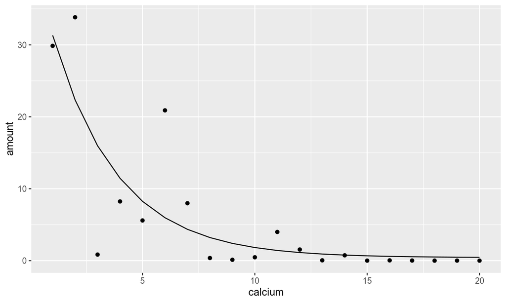

```r
ggplot(cbind(amount, fit = fitted(fit.nls)), aes(x = calcium, y = amount)) +
  geom_point() +
  geom_line(aes(y = fit))
```

1. Is there a natural expression
2. Identify parameters
3. Roughly estimate parameters
4. Start NLS